## NYPD Shooting Incidents Report

This is a report on data from the NYPD regarding Shooting Incidents. In this report I will use various techniques to clean, transform, analyze and visualize data to identify trends.

Firstly, the data needs to be loaded from its URL, I will also load all packages needed for my report.

Next I will look at a sample of my data to see the columns in my data frame.

```r
head(shooting_data)
```

|  | INCIDENT_KEY | OCCUR_DATE | OCCUR_TIME | BORO | LOC_OF_OCCUR_DESC | PRECINCT | JURISDICTION_CODE | LOC_CLASSFCTN_DESC | LOCATION_DESC | STATISTICAL_MURDER_FLAG | PERP_AGE_GROUP | PERP_SEX | PERP_RACE | VIC_AGE_GROUP | VIC_SEX | VIC_RACE | X_COORD_CD | Y_COORD_CD | Latitude | Longitude | Lon_Lat |
| --- | --- | --- | --- | --- | --- | --- | --- | --- | --- | --- | --- | --- | --- | --- | --- | --- | --- | --- | --- | --- | --- |
| 1 | 228798151 | 05/27/2021 | 21:30:00 | QUEENS |  | 105 | 0 |  |  | false |  |  |  | 18-24 | M | BLACK | 1058925 | 180924.0 | 40.66296 | -73.73084 | POINT (-73.73083868899994 40.662964620000025) |
| 2 | 137471050 | 06/27/2014 | 17:40:00 | BRONX |  | 40 | 0 |  |  | false |  |  |  | 18-24 | M | BLACK | 1005028 | 234516.0 | 40.81035 | -73.92494 | POINT (-73.92494232599995 40.81035186300006) |
| 3 | 147998800 | 11/21/2015 | 03:56:00 | QUEENS |  | 108 | 0 |  |  | true |  |  |  | 25-44 | M | WHITE | 1007668 | 209836.5 | 40.74261 | -73.91549 | POINT (-73.91549174199997 40.74260663300004) |
| 4 | 146837977 | 10/09/2015 | 18:30:00 | BRONX |  | 44 | 0 |  |  | false |  |  |  | <18 | M | WHITE HISPANIC | 1006537 | 244511.1 | 40.83778 | -73.91946 | POINT (-73.91945661499994 40.83778200300003) |
| 5 | 58921844 | 02/19/2009 | 22:58:00 | BRONX |  | 47 | 0 |  |  | true | 25-44 | M | BLACK | 45-64 | M | BLACK | 1024922 | 262189.4 | 40.88624 | -73.85291 | POINT (-73.85290950899997 40.88623791800006) |
| 6 | 219559682 | 10/21/2020 | 21:36:00 | BROOKLYN |  | 81 | 0 |  |  | true |  |  |  | 25-44 | M | BLACK | 1004234 | 186461.7 | 40.67846 | -73.92795 | POINT (-73.92795224099996 40.678456718000064) |

Next I will use the ‘summary()’ command to view the columns and see statistical values on each column, these values are only available for columns which comprise of integers as you cannot find the mean of a set of strings.

```r
summary(shooting_data)
```

```
##   INCIDENT_KEY        OCCUR_DATE         OCCUR_TIME            BORO
##  Min.   :  9953245   Length:27312       Length:27312       Length:27312
##  1st Qu.: 63860880   Class :character   Class :character   Class :character
##  Median : 90372218   Mode  :character   Mode  :character   Mode  :character
##  Mean   :120860536
##  3rd Qu.:188810230
##  Max.   :261190187
##
##  LOC_OF_OCCUR_DESC     PRECINCT      JURISDICTION_CODE LOC_CLASSFCTN_DESC
##  Length:27312       Min.   :  1.00   Min.   :0.0000    Length:27312
##  Class :character   1st Qu.: 44.00   1st Qu.:0.0000    Class :character
##  Mode  :character   Median : 68.00   Median :0.0000    Mode  :character
##                     Mean   : 65.64   Mean   :0.3269
##                     3rd Qu.: 81.00   3rd Qu.:0.0000
##                     Max.   :123.00   Max.   :2.0000
##                                      NA's   :2
##  LOCATION_DESC      STATISTICAL_MURDER_FLAG PERP_AGE_GROUP
##  Length:27312       Length:27312            Length:27312
##  Class :character   Class :character        Class :character
##  Mode  :character   Mode  :character        Mode  :character
##
##
##
##
##    PERP_SEX          PERP_RACE         VIC_AGE_GROUP        VIC_SEX
##  Length:27312       Length:27312       Length:27312       Length:27312
##  Class :character   Class :character   Class :character   Class :character
##  Mode  :character   Mode  :character   Mode  :character   Mode  :character
##
##
##
##
##    VIC_RACE           X_COORD_CD        Y_COORD_CD        Latitude
##  Length:27312       Min.   : 914928   Min.   :125757   Min.   :40.51
##  Class :character   1st Qu.:1000028   1st Qu.:182834   1st Qu.:40.67
##  Mode  :character   Median :1007731   Median :194487   Median :40.70
##                     Mean   :1009449   Mean   :208127   Mean   :40.74
##                     3rd Qu.:1016838   3rd Qu.:239518   3rd Qu.:40.82
##                     Max.   :1066815   Max.   :271128   Max.   :40.91
##                                                        NA's   :10
##    Longitude        Lon_Lat
##  Min.   :-74.25   Length:27312
##  1st Qu.:-73.94   Class :character
##  Median :-73.92   Mode  :character
##  Mean   :-73.91
##  3rd Qu.:-73.88
##  Max.   :-73.70
##  NA's   :10
```

Certain columns provide no data that can help our report, such as ‘INCIDENT_KEY’ or ‘JURISDICTION_CODE’, therefore we can omit these columns to make our data more relevant.

```r
shooting_data <- subset(shooting_data, select = -c(INCIDENT_KEY,LOC_OF_OCCUR_DESC,STATISTICAL_MURDER_FLAG,
                                                   JURISDICTION_CODE,LOC_CLASSFCTN_DESC, LOCATION_DESC,
                                                   X_COORD_CD, Y_COORD_CD,PRECINCT, Lon_Lat, OCCUR_TIME))
```

Now we have removed the columns which we have no use for we need to clean the data of the columns in our new data frame, we will do this by removing rows with NULL or blank values as they may skew our results.

```r
shooting_data[shooting_data == ''] <- NA
shooting_data[shooting_data == '(null)'] <- NA
shooting_data[shooting_data == 'U'] <- NA
shooting_data[shooting_data == 'UNKNOWN'] <- NA

shooting_data <- shooting_data[complete.cases(shooting_data),]
```

In the summary provided we can see that certain columns are stored as characters when they should be stored as other values, such as OCCUR_DATE. I will also make a new column to show the year of the murder to make it easier to use later in data visualisations.

```r
shooting_data$OCCUR_DATE <- as.Date(shooting_data$OCCUR_DATE, format = '%m/%d/%Y')
shooting_data$YEAR <- format(shooting_data$OCCUR_DATE, '%Y')
```

Now that our data is cleaned and sorted we can begin analyzing it.

First we will look at which gender is more likely to be the perpetrator in a shooting incident and which gender is more likely to be a victim in a shooting incident.

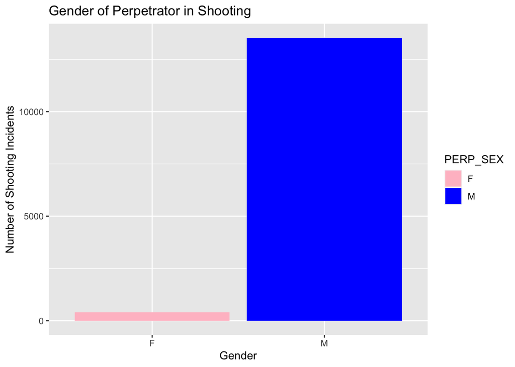

```r
ggplot(shooting_data, aes(x = PERP_SEX, fill = PERP_SEX))+
  geom_bar()+
  labs(title = 'Gender of Perpetrator in Shooting', x = 'Gender', y = 'Number of Shooting Incidents')+
  scale_fill_manual(values = c('pink','blue'))
```

Here we can see that men are the perpetrator in the vast majority of these shootings. Lets see what the proportion of males to females looks like for victims of a shooting incident.

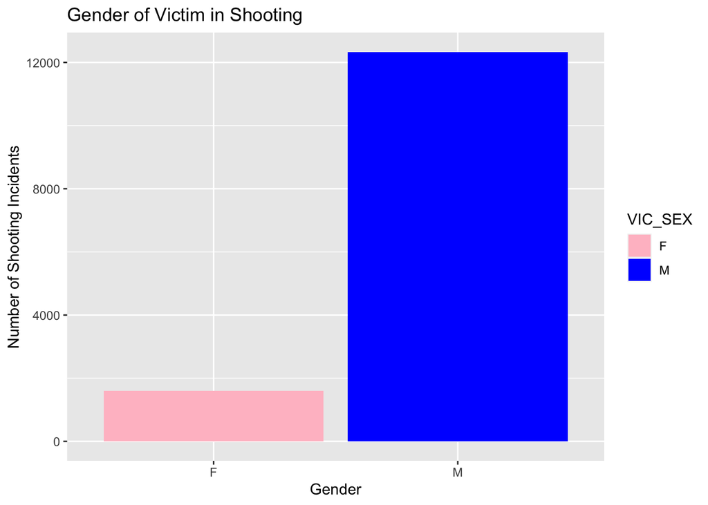

```r
ggplot(shooting_data, aes(x = VIC_SEX, fill = VIC_SEX))+
  geom_bar()+
  labs(title = 'Gender of Victim in Shooting', x = 'Gender', y = 'Number of Shooting Incidents')+
  scale_fill_manual(values = c('pink','blue'))
```

Interestingly here we see that once again main account for the vast majority of victims in these shooting incidents. However we can see that women actually account for more of the victims of shooting incidents than they account for the perpetrators of shooting incidents. Overall however women are far less likely to be involved in a shooting incident at all.

The following graphs will illustrate the racial distributions of both the perpetrators and victims in a shooting incident.

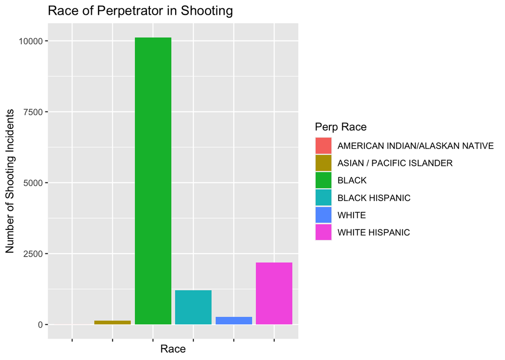

```r
ggplot(shooting_data, aes(x = PERP_RACE, fill = PERP_RACE))+
  geom_bar()+
  labs(title = 'Race of Perpetrator in Shooting', x = 'Race', y = 'Number of Shooting Incidents', fill = 'Perp Race') +
  theme(axis.text.x = element_blank())
```

Here we can see that the perpetrator is Black in the majority of shooting incidents, this is then followed by White Hispanic, Black Hispanic, White, Asian / Pacific Islander which is then followed by the race with the least number of shooting perpetrators, American Indians.

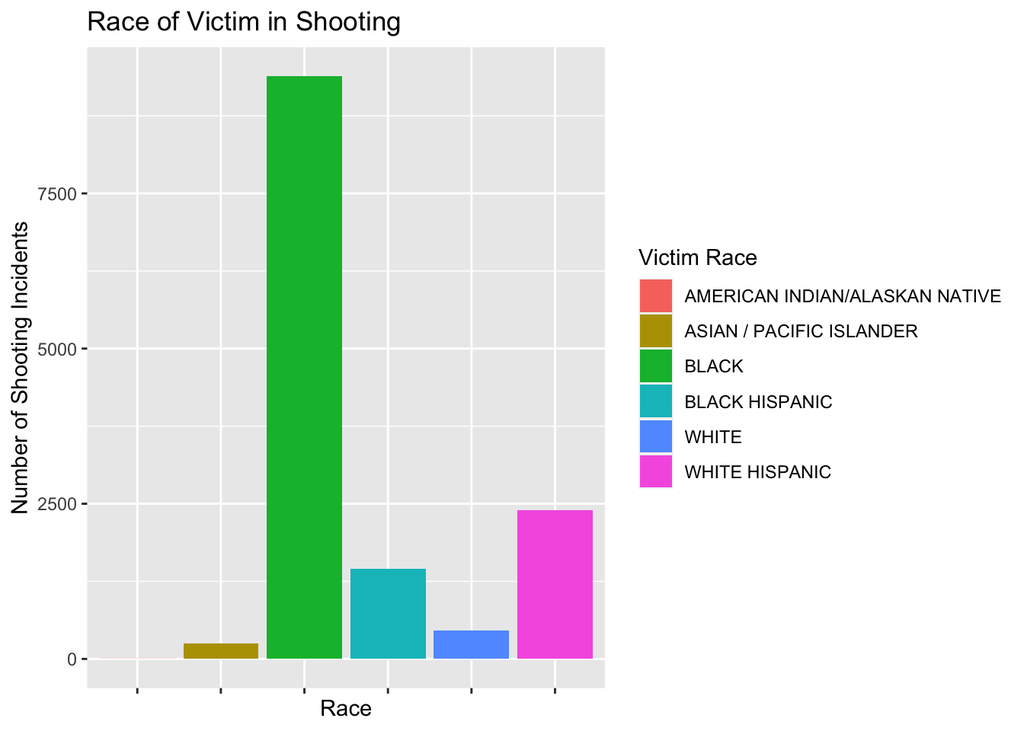

```r
ggplot(shooting_data, aes(x = VIC_RACE, fill = VIC_RACE))+
  geom_bar()+
  labs(title = 'Race of Victim in Shooting', x = 'Race', y = 'Number of Shooting Incidents', fill = 'Victim Race') +
  theme(axis.text.x = element_blank())
```

Here we can see that the race that was the victim in the most shooting incidents was Black, White Hispanics were next which were followed by Black Hispanics, next up were people who were White. American Indians where the least likely to be the victim in a shooting incident.

From both of these graphs we can see that Black people are the most likely to be the perpetrator and the victim in a shooting incident in New York and American Indians are the least likely to be either the perpetrator and the victim.

In the next segment I will explore if there is a relation between certain places and high shooting incident rates, first we will start off by seeing the distribution of shooting incidents between boroughs.

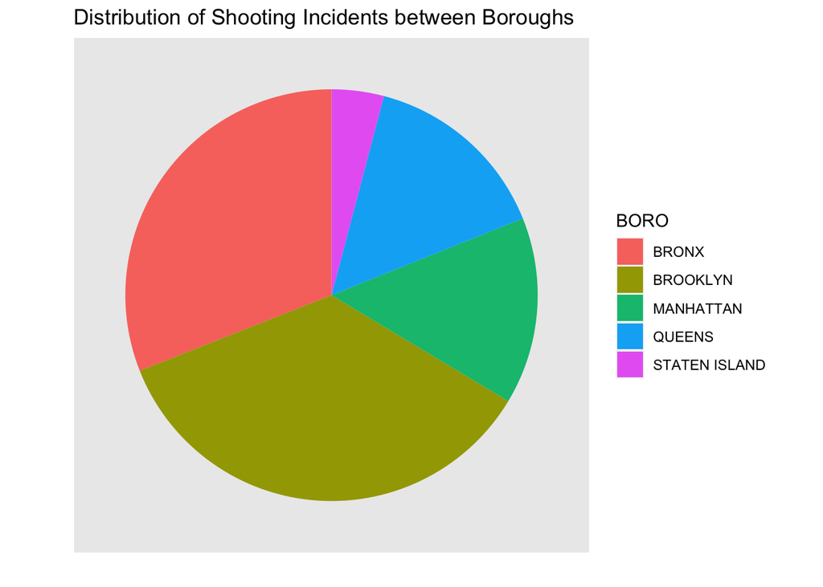

```r
ggplot(shooting_data, aes(x='',fill = BORO))+
  geom_bar(width=1, stat = 'count')+
  coord_polar(theta = 'y')+
  labs(title = 'Distribution of Shooting Incidents between Boroughs', x = '', y = '')+
  theme(axis.text = element_blank(),
        axis.ticks = element_blank(),
        panel.grid = element_blank())+
  scale_y_continuous(labels = scales::percent_format(scale = 1))
```

Here we can see that the majority of shooting incidents took place in Brooklyn, followed by the Bronx, next is manhattan which is closely followed by Queens and the area with the lowest amount of shootings is Staten Island.

```r
map <- leaflet(shooting_data, width = 500, height = 500) %>%
  setView(lng = -74.006, lat = 40.6828, zoom = 10.2) %>%
  addTiles() %>%
  addHeatmap(
    lng = ~Longitude,
    lat = ~Latitude,
    radius = 3,
    gradient = 'red',
    minOpacity = 0.05
  )

map
```

[interactive chart not shown]

Finally we will explore if the number of shooting incidents per year has increased or decreased over time.

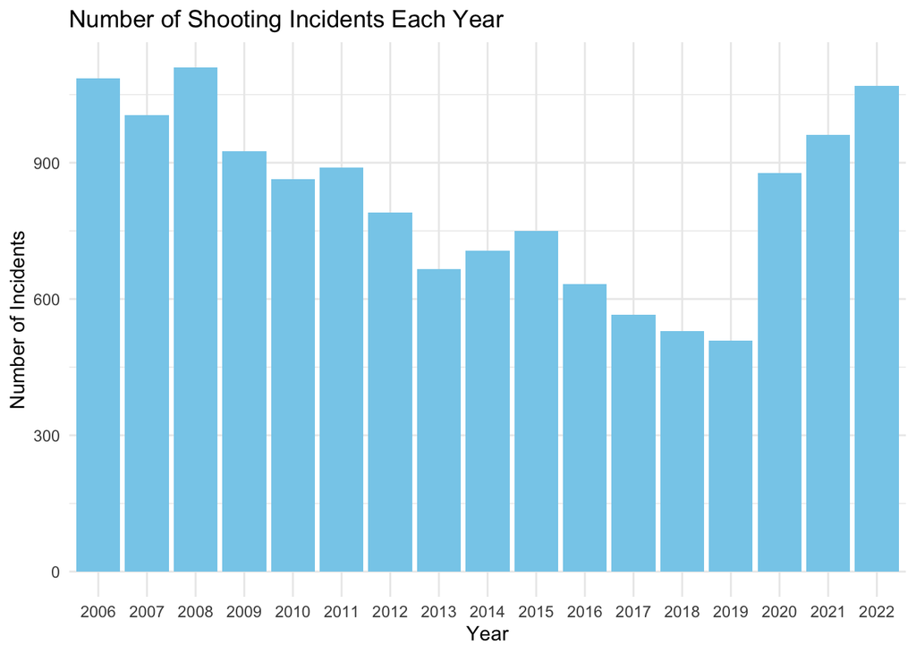

```r
ggplot(shooting_data, aes(x=YEAR))+
  geom_bar(stat = 'count', fill = 'skyblue')+
  labs(title = 'Number of Shooting Incidents Each Year',
       x = 'Year',
       y = 'Number of Incidents')+
  theme_minimal()
```